# R Notebook

## Fit binomial(link=“probit”)

```r
model_fit_probit_link <- glm(data = project_data_train,
  formula = repay_fail ~ .,
  family = binomial(link="probit"),
  control = glm.control(maxit = 50)
  )
```

### Model Summary

```r
summary(model_fit_probit_link)
```

```
Call:
glm(formula = repay_fail ~ ., family = binomial(link = "probit"),
    data = project_data_train, control = glm.control(maxit = 50))

Deviance Residuals:
    Min       1Q   Median       3Q      Max
-3.1593  -0.4074  -0.0770  -0.0001   8.1058

Coefficients:
                                     Estimate Std. Error z value Pr(>|z|)
(Intercept)                        -2.770e-01  1.101e-01  -2.517 0.011851 *
term60 months                      -6.570e-02  4.219e-02  -1.557 0.119466
int_rate                            7.826e-03  5.776e-03   1.355 0.175431
emp_length< 1 year                 -1.606e-01  5.102e-02  -3.148 0.001644 **
emp_length1 year                   -4.822e-02  5.593e-02  -0.862 0.388645
emp_length2 years                  -1.384e-01  5.219e-02  -2.651 0.008016 **
emp_length3 years                  -1.105e-01  5.444e-02  -2.030 0.042370 *
emp_length4 years                  -6.821e-02  5.729e-02  -1.191 0.233780
emp_length5 years                  -5.902e-02  5.734e-02  -1.029 0.303354
emp_length6 years                  -1.065e-01  6.702e-02  -1.590 0.111871
emp_length7 years                  -3.832e-03  7.258e-02  -0.053 0.957894
emp_length8 years                  -1.187e-02  7.962e-02  -0.149 0.881486
emp_length9 years                  -7.527e-02  9.180e-02  -0.820 0.412233
emp_lengthn/a                      -7.300e-02  7.893e-02  -0.925 0.355014
home_ownershipNONE                  4.342e-01  8.691e-01   0.500 0.617399
home_ownershipOTHER                 2.262e-01  1.918e-01   1.180 0.238161
home_ownershipOWN                   1.248e-02  5.474e-02   0.228 0.819588
home_ownershipRENT                  1.603e-02  3.290e-02   0.487 0.626071
annual_inc                          3.323e-07  2.564e-07   1.296 0.195058
verification_statusSource Verified  2.398e-02  3.451e-02   0.695 0.487122
verification_statusVerified         3.344e-01  3.525e-02   9.488  < 2e-16 ***
purposecredit_card                  3.303e-01  8.097e-02   4.079 4.52e-05 ***
purposedebt_consolidation           5.800e-01  7.208e-02   8.047 8.50e-16 ***
purposeeducational                  4.333e-01  1.282e-01   3.379 0.000728 ***
purposehome_improvement             2.560e-01  8.577e-02   2.985 0.002835 **
purposehouse                        2.757e-01  1.636e-01   1.686 0.091876 .
purposemajor_purchase              -4.504e-03  8.932e-02  -0.050 0.959787
purposemedical                      2.124e-01  1.133e-01   1.875 0.060783 .
purposemoving                       1.016e-02  1.202e-01   0.085 0.932633
purposeother                        1.989e-01  7.780e-02   2.557 0.010567 *
```

[output cut: 11 more lines]

```
total_acc                           7.600e-03  1.887e-03   4.028 5.63e-05 ***
total_rec_prncp                    -3.508e-04  7.722e-06 -45.425  < 2e-16 ***
total_rec_int                       5.086e-04  1.612e-05  31.551  < 2e-16 ***
last_pymnt_amnt                    -2.865e-04  1.892e-05 -15.141  < 2e-16 ***
credit_age_yrs                      2.233e-03  2.336e-03   0.956 0.339093
---
Signif. codes:  0 ‘***’ 0.001 ‘**’ 0.01 ‘*’ 0.05 ‘.’ 0.1 ‘ ’ 1

(Dispersion parameter for binomial family taken to be 1)

    Null deviance: 19599  on 23081  degrees of freedom
Residual deviance: 10366  on 23036  degrees of freedom
AIC: 10458

Number of Fisher Scoring iterations: 9
```

#### Confusion Matrix

```r
model_preds_train_probit = 1 / (1+ (1/exp(predict(model_fit_probit_link)) ) )
model_preds_train_probit[model_preds_train_probit > 0.5] <- 1
model_preds_train_probit[model_preds_train_probit <= 0.5] <- 0
caret::confusionMatrix(data = model_preds_train_probit, reference = project_data_train$repay_fail)
```

```
Confusion Matrix and Statistics

          Reference
Prediction     0     1
         0 19208  1400
         1   387  2087

               Accuracy : 0.9226
                 95% CI : (0.9191, 0.926)
    No Information Rate : 0.8489
    P-Value [Acc > NIR] : < 2.2e-16

                  Kappa : 0.6572
 Mcnemar's Test P-Value : < 2.2e-16

            Sensitivity : 0.9803
            Specificity : 0.5985
         Pos Pred Value : 0.9321
         Neg Pred Value : 0.8436
             Prevalence : 0.8489
         Detection Rate : 0.8322
   Detection Prevalence : 0.8928
      Balanced Accuracy : 0.7894

       'Positive' Class : 0
```

```r
model_preds_val_probit = 1 / (1+ (1/exp(predict(model_fit_probit_link, newdata = project_data_val)) ) )
model_preds_val_probit[model_preds_val_probit > 0.5] <- 1
model_preds_val_probit[model_preds_val_probit <= 0.5] <- 0
caret::confusionMatrix(data = model_preds_val, reference = project_data_val$repay_fail)
```

[output not shown]

# Comparing Link Funcitons?

# Old notes p251 for link comparison

# Goodness of fit?

# stepwise selection

```r
#From stepwise regression: AIC 16100

glm(formula = repay_fail ~ `term60 months` + int_rate + `emp_length< 1 year` + `emp_length< 1 year`*annual_inc +
    `emp_length2 years` + `emp_length6 years` + home_ownershipOTHER +
    annual_inc + `verification_statusSource Verified` + verification_statusVerified +
    purposecredit_card + purposedebt_consolidation + purposeeducational +
    purposehome_improvement + purposehouse + purposemedical +
    purposeother + purposesmall_business + purposevacation +
    purposewedding + delinq_2yrs + inq_last_6mths + open_acc +
    pub_rec + revol_bal + revol_util + total_acc + total_rec_prncp +
    total_rec_int + last_pymnt_amnt, family = "binomial", data = train_frame_alt,
    control = glm.control(maxit = 50)) -> mdl
```

# model diagnostics

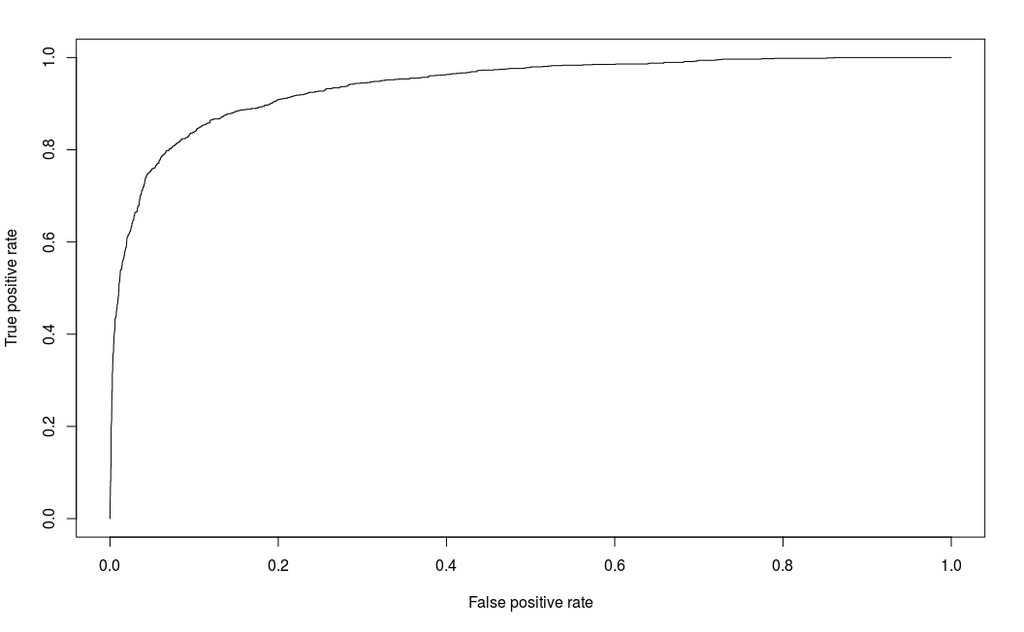

```r
model_preds_val = 1 / (1+ (1/exp(predict(model_fit, newdata = project_data_val)) ) )
model_preds_val_probit = 1 / (1+ (1/exp(predict(model_fit_probit_link, newdata = project_data_val)) ) )
library(ROCR)
val_pred_ob <- prediction(predictions = model_preds_val, labels = project_data_val$repay_fail)
perf <- performance(val_pred_ob, measure = "tpr", x.measure = "fpr")
plot(perf)
```

## Gini index

```r
AUROC <- performance(val_pred_ob, measure = "auc")
gini <- 2* (AUROC@y.values[[1]] - 0.5)
#Ratio of model area to random line area * 2 to scale from 0-1
gini
```

```
[1] 0.8792835
```

## Gini for probit

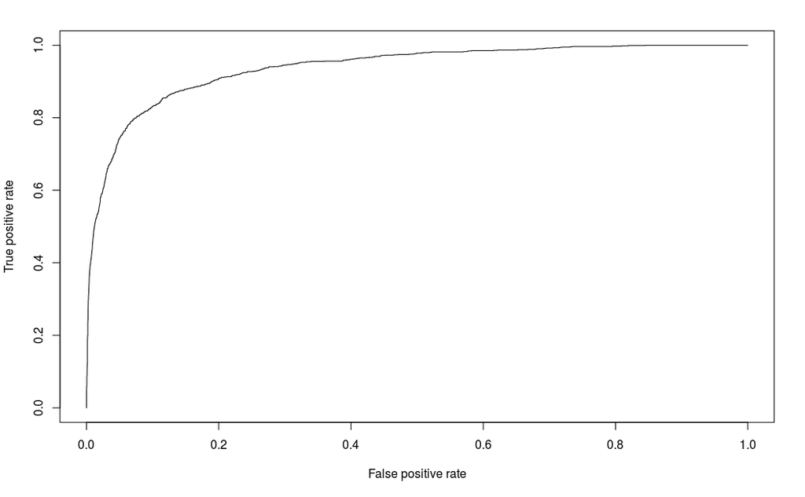

```r
val_pred_ob_probit <- prediction(predictions = model_preds_val_probit , labels = project_data_val$repay_fail)
perf_probit <- performance(val_pred_ob_probit, measure = "tpr", x.measure = "fpr")
plot(perf_probit)
```

```r
AUROC <- performance(val_pred_ob_probit, measure = "auc")
gini <- 2* (AUROC@y.values[[1]] - 0.5)
#Ratio of model area to random line area * 2 to scale from 0-1
gini
```

```
[1] 0.8746308
```

## Probit vs Logit ROC

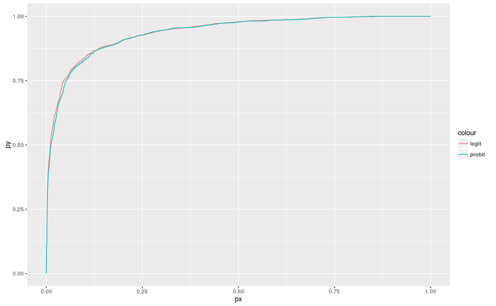

```r
comp_data <- data_frame(
  px = perf@x.values[[1]],
  py = perf@y.values[[1]],
  probx = perf_probit@x.values[[1]],
  proby = perf_probit@y.values[[1]]
)
ggplot(comp_data) +
  geom_line(aes(x=px,y=py,colour="logit")) +
  geom_line(aes(x=probx,y=proby,colour="probit"))
```

```r
#basically identical prediction quality.
```

## Jamess Qauntile comaprison

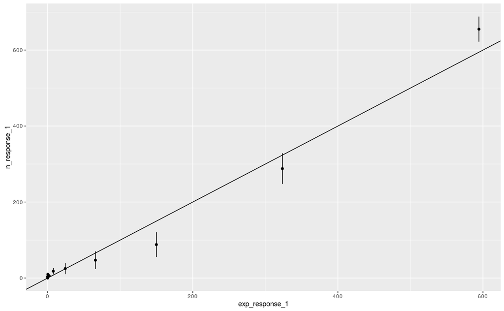

```r
comp_df <- data_frame(
  linear_predictor = model_preds_val,
  response = project_data_val$repay_fail
)
comp_df %>%
  arrange(linear_predictor) %>%
  mutate(pc = ntile(linear_predictor,10)) %>%
  group_by(pc) %>%
  summarise(n_response_1 = sum(response),
            exp_response_1 = sum(linear_predictor),
            exp_variance = sum(linear_predictor*(1-linear_predictor)) ) %>%
  ggplot() + geom_point(aes(x=exp_response_1,y=n_response_1)) +
  geom_errorbar(aes(y=n_response_1,
                      x=exp_response_1,
                      ymax = n_response_1 + 3*sqrt(exp_variance),
                      ymin = n_response_1 - 3*sqrt(exp_variance)
                      )) +
  geom_abline(slope = 1, intercept = 0)
```

# Burton Wu’s assignment ideas

What I am thinking is Option 3. This is for several reasons:

Introduce Kaggle to the students However the data size is too big which means classical statistics (eg p-values) will fail Consequently, I am proposing to modify the dataset such that it has say around 5,000 observations only Around the “max” where you can relay on p-values but big enough to look for an alternative measures Add “test data” (or other unusual data) into the dataset which the students need to identify and remove Make some records contain missing values Add a couple categorical variables Assignment can be very similar to the insurance group? assignment from a few years ago (ie a pretty standard assignment) but with the following changes:

Similar to prior assignments, the student needs to run all three models: logit, probit, and cloglog Goodness of fit - likelihood ratio, scaled deviance, etc Model adequacy - look at transformation, add interaction, residual, etc Final model selection However, the key additions to the assignment are:

Large Dataset: Discuss the impact to p-value for example when dealing with large dataset Make use of validation sample - this “machine learning” concept is not currently being taught in maths Use of Gini and Information Value (IV) in addition to p-value Data Issue: Need to handle special values, missing values, etc Need to exclude “test” or staff observations for example Business: Why the industry may prefer one model (ie logit) over others? Because the output is often a scorecard, but the student will not be convert the model to a scorecard else the project will be way too long Talk about the variables. The student should think about what other variables might be useful that are not in the dataset. The reason is that in the industry, we often need to construct the modelling dataset ourselves. Some literature review/paper searching will be good for maths student who most likely has not used database before